# Explainable Machine Learning - Homework 1

## Part 1: Dataset

I have selected the `spambase.csv` dataset for my analysis. This dataset comprises 54 columns, with most of them following the format `word_freq_{word}` indicating the frequency of common words in emails. Additionally, there is a column named `capital_run_length_average` which represents the average length of a sequence of capital letters within each email. The `TARGET` column serves as the target variable for prediction, involving a binary classification task to determine whether an email is classified as spam or not. The original dataset contains 4600 observations, but the train set size for this exercise has been limited to 1024 observations to ensure that TabFPN can handle the data without any memory issues.

## Part 2: Models

Below is a list of the models used for binary classification in the `spambase.csv` dataset.

Each model was trained on the dataset, and their performance was assessed using various metrics, including accuracy, ROC curves, and confusion matrices.

1. **Logistic Regression** - A simple linear model for binary classification.
2. **Gradient Boosted Decision Trees (LightGBM)** - A gradient boosting framework for efficient and fast handling of large datasets.
3. **TabPFN (Tabular Predictive Feedforward Networks)** - A specialized model for tabular data, combining predictive networks and ensemble methods.

## Part 3: Evaluation

In this section, I assess the performance of the models and present the results of my analysis. Each model's evaluation is based on various metrics to provide a comprehensive understanding of their effectiveness in classifying spam emails.

Logistic Regression:

[output not shown]

LightGBM:

[output not shown]

TabFPN:

[output not shown]

### Confusion Matrices

Confusion matrices are used to visualize the models' classification results. They provide insights into true positives, true negatives, false positives, and false negatives, allowing me to assess the models' precision and recall.

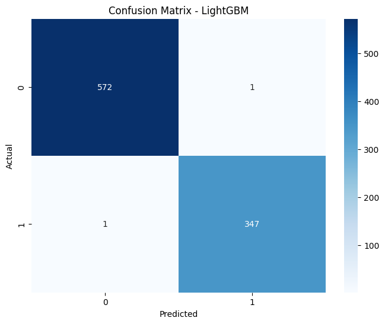

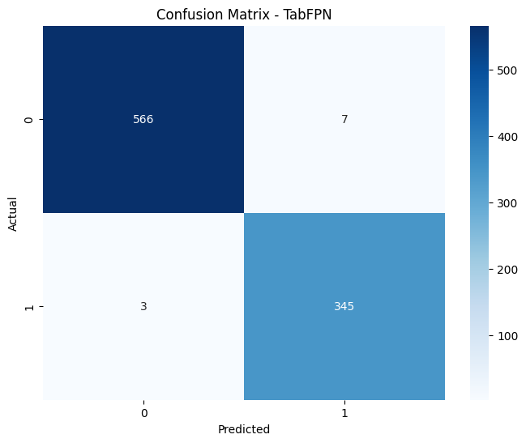

[figure not shown]

### Receiver Operating Characteristic (ROC) Curves

ROC curves depict the trade-off between true positive rate and false positive rate. The area under the ROC curve (AUC) is a valuable metric for evaluating model performance. A higher AUC suggests better discrimination ability.

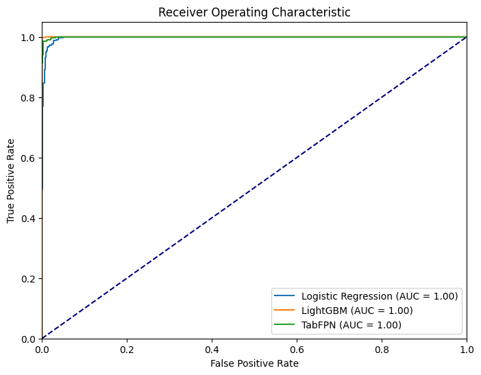

## Part 4: Analysis

While assessing model performance, it becomes evident that Logistic Regression, while being the least accurate among the three models, still achieved remarkable results by misclassifying only 20 test observations. The second-best performer, TabFPN, exhibited a notable accuracy by misclassifying just 10 observations. The top-performing model, LightGBM, demonstrated exceptional precision by misclassifying only 2 observations. These findings are reinforced when examining the ROC curves for each model.

## Part 5: Appendix

This section includes the reproducible R/Python code used to implement the analysis.

```
# Prepare the environment:
#
# !pip install tabpfn lightgbm seaborn
#
# !wget https://raw.githubusercontent.com/adrianstando/imbalanced-benchmarking-set/main/datasets/spambase.csv

import pandas as pd
import numpy as np
import seaborn as sns
from sklearn.model_selection import train_test_split
from sklearn.linear_model import LogisticRegression
from tabpfn import TabPFNClassifier
from sklearn.metrics import accuracy_score, classification_report, roc_curve, auc
import matplotlib.pyplot as plt
from sklearn.metrics import confusion_matrix
from lightgbm import LGBMClassifier

spambase_df = pd.read_csv("spambase.csv")

features = spambase_df.drop("TARGET", axis=1).to_numpy()
targets = spambase_df[["TARGET"]].to_numpy()

train_features, test_features, train_targets, test_targets = train_test_split(features, targets, test_size=0.2)
train_features = train_features[:1024]
train_targets = train_targets[:1024]

predictions = {}

model = LogisticRegression()
model.fit(train_features, train_targets.ravel())
predictions["Logistic Regression"] = model.predict_proba(test_features)[:, 1]

model = LGBMClassifier()
model.fit(train_features, train_targets.ravel())
predictions["LightGBM"] = model.predict_proba(test_features)[:, 1]

model = TabPFNClassifier(device='cuda', N_ensemble_configurations=32)
model.fit(train_features, train_targets.ravel())
predictions["TabFPN"] = model.predict_proba(test_features)[:, 1]

for model_name, model_predictions in predictions.items():
    print(f"{model_name}:")
    print(classification_report(test_targets, np.round(model_predictions)))

for model_name, model_predictions in predictions.items():
    conf_matrix = confusion_matrix(test_targets, np.round(model_predictions))

    plt.figure(figsize=(8, 6))
    sns.heatmap(conf_matrix, annot=True, fmt="d", cmap="Blues")
    plt.xlabel("Predicted")
    plt.ylabel("Actual")
    plt.title(f"Confusion Matrix - {model_name}")
    plt.show()

roc_curves = {}

for model_name, model_predictions in predictions.items():
    fpr, tpr, _ = roc_curve(test_targets, model_predictions)
    roc_auc = auc(fpr, tpr)

    roc_curves[model_name] = (fpr, tpr, roc_auc)

plt.figure(figsize=(8, 6))
for model_name, (fpr, tpr, roc_auc) in roc_curves.items():
    plt.plot(fpr, tpr, label=f'{model_name} (AUC = {roc_auc:.2f})')

plt.plot([0, 1], [0, 1], color='navy', linestyle='--')
plt.xlim([0.0, 1.0])
plt.ylim([0.0, 1.05])
plt.xlabel('False Positive Rate')
plt.ylabel('True Positive Rate')
plt.title('Receiver Operating Characteristic')
plt.legend(loc="lower right")
plt.show()
```